# Association between miRNA transcription and miRNA activity across TCGA tumors

Gabrielle Perron

2026-September-24

# 1 Load libraries

```r
library(rtracklayer)
library(GenomicRanges)
library(data.table)
library(purrr)
library(tibble)
library(tidyr)
library(stringr)
library(dplyr)
library(gplots)
library(ggplot2)
```

# 2 Select miRNA host genes that contain miRNA loci within introns

We use the miRNA annotation from miRBase ftp://mirbase.smith.man.ac.uk/pub/mirbase/CURRENT/genomes/

```r
# Load the miRBase annotation
mir_annot <- import(here("data", "hsa.gff3"))
mir_annot <- as.data.frame(mir_annot)

# Select for pri-miRNAs
pri_mir_annot <- mir_annot %>% filter(type == "miRNA_primary_transcript")

head(pri_mir_annot)
```

```
##   seqnames   start     end width strand source                     type score
## 1     chr1   17369   17436    68      -   <NA> miRNA_primary_transcript    NA
## 2     chr1   30366   30503   138      +   <NA> miRNA_primary_transcript    NA
## 3     chr1  187891  187958    68      -   <NA> miRNA_primary_transcript    NA
## 4     chr1  632615  632685    71      -   <NA> miRNA_primary_transcript    NA
## 5     chr1 1167104 1167198    95      +   <NA> miRNA_primary_transcript    NA
## 6     chr1 1167863 1167952    90      +   <NA> miRNA_primary_transcript    NA
##   phase        ID     Alias           Name Derives_from
## 1    NA MI0022705 MI0022705 hsa-mir-6859-1         <NA>
## 2    NA MI0006363 MI0006363 hsa-mir-1302-2         <NA>
## 3    NA MI0026420 MI0026420 hsa-mir-6859-2         <NA>
## 4    NA MI0039740 MI0039740  hsa-mir-12136         <NA>
## 5    NA MI0000342 MI0000342   hsa-mir-200b         <NA>
## 6    NA MI0000737 MI0000737   hsa-mir-200a         <NA>
```

```r
# Load the intron annotation
intron_annot <- import(here("data", "Homo_sapiens.GRCh38.85.chr.Introns.gtf"))
intron_annot <- as.data.frame(intron_annot)

head(intron_annot)
```

```
##   seqnames  start    end width strand         source   type score phase
## 1     chr1 944801 945056   256      - ensembl_havana intron    NA    NA
## 2     chr1 945147 945517   371      - ensembl_havana intron    NA    NA
## 3     chr1 945654 946172   519      - ensembl_havana intron    NA    NA
## 4     chr1 946287 946401   115      - ensembl_havana intron    NA    NA
## 5     chr1 946546 948130  1585      - ensembl_havana intron    NA    NA
## 6     chr1 948233 948489   257      - ensembl_havana intron    NA    NA
##           gene_id
## 1 ENSG00000188976
## 2 ENSG00000188976
## 3 ENSG00000188976
## 4 ENSG00000188976
## 5 ENSG00000188976
## 6 ENSG00000188976
```

```r
# Use GenomicRanges to detect coordinate overlap
pri_mir_gr <- GRanges(
  seqnames = pri_mir_annot$seqnames,
  ranges = IRanges(start = pri_mir_annot$start, end = pri_mir_annot$end),
  strand = pri_mir_annot$strand,
  pri_mir_id = pri_mir_annot$Name
)

intron_gr <- GRanges(
  seqnames = intron_annot$seqnames,
  ranges = IRanges(start = intron_annot$start, end = intron_annot$end),
  strand = intron_annot$strand,
  gene_id = intron_annot$gene_id
)

# Find all pri-miRNAs contained within introns
overlaps <- findOverlaps(pri_mir_gr, intron_gr, type = "within")
mir_gene_pairs <- as.data.frame(overlaps) |>
  mutate(
    pri_mir_id = pri_mir_gr$pri_mir_id[queryHits],
    gene_id = intron_gr$gene_id[subjectHits]
  ) |>
  select(gene_id, pri_mir_id)

# Save
write.csv(mir_gene_pairs, file=here("TCGA", "output", "supplementary_tables", "GRCh38_miRs_in_introns.csv"))
```

# 3 Load the estimates of changes in mRNA abundance (dfe) and transcription (dfi) across TCGA tumors, from BETAS

```r
dfi_files <- Sys.glob(here("data", "TCGA-*.BETAS_dfi.csv"))
dfe_files <- Sys.glob(here("data", "TCGA-*.BETAS_dfe.csv"))
stopifnot(all(gsub("BETAS.*", "", dfi_files) == gsub("BETAS.*", "", dfe_files)))

# Extract cancer type from filename
cancers <- dfi_files |>
  basename() |>
  str_extract("TCGA-[A-Z]+") |>
  str_remove("TCGA-")

# Load dfi and dfe data, indicate cancer type
dfi_data_list <- map2(dfi_files, cancers, function(f, cancer) {
  fread(f) |>
    as.data.frame() |>
    (\(dt) {rownames(dt) <- dt[[1]]; dt[, -1]})() |>
    as.matrix() |>
    as.data.frame() |>
    rownames_to_column("gene_id") |>
    mutate(cancer = cancer)
})

dfe_data_list <- map2(dfe_files, cancers, function(f, cancer) {
  fread(f) |>
    as.data.frame() |>
    (\(dt) {rownames(dt) <- dt[[1]]; dt[, -1]})() |>
    as.matrix() |>
    as.data.frame() |>
    rownames_to_column("gene_id") |>
    mutate(cancer = cancer)
})

# Combine into long tables
# Pivot each data frame before binding
dfi_long <- map_df(dfi_data_list, ~{
  .x |>
    pivot_longer(-c(gene_id, cancer), names_to = "sample", values_to = "dfi")
})

saveRDS(dfi_long, here("TCGA", "output", "rds", "TCGA_dfi_long.rds"))

dfe_long <- map_df(dfe_data_list, ~{
  .x |>
    pivot_longer(-c(gene_id, cancer), names_to = "sample", values_to = "dfe")
})
```

# 4 For each cancer type, for each miRNA host gene, test the correlation between changes in mRNA abundance (dfe) and transcription (dfi) across tumor samples

```r
# Compute correlations for each gene-cancer combination
stopifnot(all(dfi_long$sample == dfe_long$sample))
stopifnot(all(dfi_long$gene_id == dfe_long$gene_id))

dfe_dfi_results <- bind_cols(
  dfi_long |> select(gene_id, cancer, sample, dfi),
  dfe_long |> select(dfe)
) |>

  # Filter to tumor samples (those ending in -01)
  filter(str_detect(sample, "\\-01$")) |>

  # Filter to genes in mir_gene_pairs
  semi_join(
    mir_gene_pairs |> select(gene_id) |> distinct() |> rename(gene_id = gene_id),
    by = "gene_id"
  ) |>

  # Remove rows where all values in a gene-cancer group are NA
  group_by(gene_id, cancer) |>
  filter(!all(is.na(dfi) | is.na(dfe))) |>

  # Compute correlation statistics
  nest(data = -c(gene_id, cancer)) |>
  mutate(
    corr_test = map(data, ~{
      dat <- .x |> filter(!is.na(dfi), !is.na(dfe))
      if (nrow(dat) < 3) return(NA)  # Need at least 3 points for correlation

      corr <- cor.test(dat$dfi, dat$dfe)
      fit <- lm(dfe ~ dfi, data = dat)

      tibble(
        correlation = corr$estimate,
        p_value = corr$p.value,
        r_squared = summary(fit)$r.squared,
        n = nrow(dat)
      )
    }),
    .keep = "unused"
  ) |>
  unnest(corr_test)

# FDR correction
dfe_dfi_results <- dfe_dfi_results |>
  mutate(
    fdr = p.adjust(p_value, method = "fdr"),
    signed_r2 = sign(correlation) * r_squared
  )
```

# 5 Heatmap of correlation coefficients for dfe vs dfi for all genes that contain a miRNA in their introns

```r
# Create matrix for heatmap
signed_r2_matrix <- dfe_dfi_results |>
  select(gene_id, cancer, signed_r2) |>
  pivot_wider(names_from = cancer, values_from = signed_r2, values_fill = NA) |>
  column_to_rownames("gene_id") |>
  as.matrix()

# Remove rows and columns with only NAs
signed_r2_matrix <- signed_r2_matrix[
  rowSums(is.na(signed_r2_matrix)) != ncol(signed_r2_matrix),
  colSums(is.na(signed_r2_matrix)) != nrow(signed_r2_matrix)
]

palette <- colorRampPalette(c("blue", "white", "red"))

pdf(here("TCGA", "output", "figures", "TCGA_miRhostGenes_dfeVSdfi_heatmap.pdf"), width = 5.5, height = 6)
heatmap.2(signed_r2_matrix, trace = "none", col = palette, cexRow = 0.01, cexCol = 1.1,
  breaks = seq(-1, 1, length.out = 100), mar = c(5, 1), keysize = 0.2,
  hclust = function(x) hclust(x, method = "average"),
  distfun = function(x) dist(x, method = "euclidean"),
  density.info = "none", key.par = list(cex = 1), lhei = c(1, 3), lwid = c(1, 1.5))
dev.off()
```

# 6 Filter miRNA-gene pairs for those where changes in abundance relative to the average (dfe) are due at least in part to changes in transcription (dfi). Specifically, retain pairs where the host gene’s dfi vs dfe correlation was significant (after FDR correction) and positive in at least 80% of cancers.

```r
dim(dfe_dfi_results)
```

```
## [1] 10761     8
```

```r
genes_sig_pos <- dfe_dfi_results |>
  filter(fdr < 0.05, correlation > 0) |>
  group_by(gene_id) |>
  summarise(sig_pos_freq = n(), .groups = "drop") |>
  # Keep genes with significant positive correlation in ≥80% of cancers
  filter(sig_pos_freq / length(cancers) >= 0.8) |>
  pull(gene_id)
length(genes_sig_pos)
```

```
## [1] 597
```

# 7 Correlation between host gene transcription changes and miRNA activity, for significant genes identified above

First make a table of host gene id, pri-miRNA id and miRNA family

```r
# Selected host genes and associated miRNA
mir_gene_pairs_sig <- mir_gene_pairs[mir_gene_pairs$gene_id %in% genes_sig_pos,]

# Load the miRNA families annotation from TargetScan
fams <- fread(here("data", "miR_Family_Info.txt"))
fams <- fams[grep("hsa-", fams$`MiRBase ID`), ]

# Format pri-miRNA IDs to better match
mir_gene_pairs_sig$pri_mir_id <- gsub("mir-", "miR-", mir_gene_pairs_sig$pri_mir_id)

# Convert pri-miRNA names to miRNA family names compatible with the activity data
fams$miR_family_2 <- gsub("/.*", "", fams$`miR family`)
fams$pri_mir_id <- gsub("-3p", "", fams$`MiRBase ID`)
fams$pri_mir_id <- gsub("-5p", "", fams$pri_mir_id)
fams <- fams[-grep("\\.1$", fams$pri_mir_id), ]
fams <- fams[-grep("\\.2$", fams$pri_mir_id), ]
fams <- fams[, c("pri_mir_id","miR_family_2")]
fams <- unique(fams)

# Merge TS families in the gene-miRNA pairs table
mir_gene_pairs_sig <- mir_gene_pairs_sig %>%
  left_join(
    fams %>%
      select(pri_mir_id, miR_family = miR_family_2),
    by = "pri_mir_id"
  )
dim(mir_gene_pairs_sig)
```

```
## [1] 1020    3
```

```r
# For the pairs that got no match (NA miR_family), try to remove the -1/2/... at the end of the pri-mir to get a match
mir_gene_pairs_sig$pri_mir_id_2 <- mir_gene_pairs_sig$pri_mir_id

idx <- is.na(mir_gene_pairs_sig$miR_family)

mir_gene_pairs_sig$pri_mir_id_2[idx] <- gsub(
  "(-[0-9]+[A-Za-z]*)-[0-9]+$",
  "\\1",
  mir_gene_pairs_sig$pri_mir_id_2[idx]
)

mir_gene_pairs_sig$miR_family[is.na(mir_gene_pairs_sig$miR_family)] <- fams$miR_family_2[match(mir_gene_pairs_sig$pri_mir_id_2[is.na(mir_gene_pairs_sig$miR_family)], fams$pri_mir_id)]
mir_gene_pairs_sig[is.na(mir_gene_pairs_sig$miR_family), ]
```

```
##              gene_id    pri_mir_id miR_family  pri_mir_id_2
## 43   ENSG00000132849 hsa-miR-12132       <NA> hsa-miR-12132
## 81   ENSG00000143340 hsa-miR-12116       <NA> hsa-miR-12116
## 130  ENSG00000095713  hsa-miR-3085       <NA>  hsa-miR-3085
## 168  ENSG00000110047 hsa-miR-10392       <NA> hsa-miR-10392
## 312  ENSG00000067141 hsa-miR-12135       <NA> hsa-miR-12135
## 476  ENSG00000105576 hsa-miR-10395       <NA> hsa-miR-10395
## 649  ENSG00000100239 hsa-miR-12114       <NA> hsa-miR-12114
## 676  ENSG00000082701  hsa-miR-6529       <NA>  hsa-miR-6529
## 771  ENSG00000113719 hsa-miR-10523       <NA> hsa-miR-10523
## 806  ENSG00000112164  hsa-miR-9983       <NA>  hsa-miR-9983
## 807  ENSG00000112561 hsa-miR-10398       <NA> hsa-miR-10398
## 843  ENSG00000006704 hsa-miR-10525       <NA> hsa-miR-10525
## 1015 ENSG00000063587 hsa-miR-12129       <NA> hsa-miR-12129
```

```r
dim(mir_gene_pairs_sig)
```

```
## [1] 1020    4
```

```r
saveRDS(mir_gene_pairs_sig, here("TCGA", "output", "rds", "TCGA_selected_miRNA_host_genes.rds"))

# Remove gene_pri-mir pairs without any found miRNA family in the TS annotation
mir_gene_pairs_sig <- mir_gene_pairs_sig[!(is.na(mir_gene_pairs_sig$miR_family)), ]
dim(mir_gene_pairs_sig)
```

```
## [1] 1007    4
```

```r
# Load miRNA activity
miR_act <- read.csv(here("TCGA", "output", "supplementary_tables", "TCGA_miRNA_activity.csv"))
miR_act$sample_name <- gsub("\\.", "-", miR_act$sample_name)

# Retain gene_pri-mir pairs that are present in the miRNA activity data
mir_gene_pairs_sig <- mir_gene_pairs_sig[mir_gene_pairs_sig$miR_family %in% miR_act$miRNA, ]
dim(mir_gene_pairs_sig)
```

```
## [1] 43  4
```

```r
# Filter for unique gene-miR family pairs
mir_gene_pairs_sig <- unique(mir_gene_pairs_sig[, c("gene_id", "miR_family")])
```

```r
# Get the dfi results for the selected host genes in mir_gene_pairs_sig, merge the host miRNA info ONTO IT
dfi_sig_hosts <- dfi_long[dfi_long$gene_id %in% mir_gene_pairs_sig$gene_id, ]

dfi_sig_hosts <- dfi_sig_hosts %>%
  left_join(
    mir_gene_pairs_sig %>%
      select(gene_id, miR_family),
    by = "gene_id",
    relationship =
  "many-to-many"
  )
dim(dfi_sig_hosts)
```

```
## [1] 319158      5
```

```r
# Merge miRNA activity results onto that based on miRNA family, cancer, and sample name
dfi_sig_hosts <- dfi_sig_hosts %>%
  left_join(
    miR_act %>%
      select(
        miRNA,
        cancer_type,
        sample_name,
        coefficient_log2
      ),
    by = c(
      "miR_family" = "miRNA",
      "cancer" = "cancer_type",
      "sample" = "sample_name"
    )
  )
dim(dfi_sig_hosts)
```

```
## [1] 319158      6
```

For each host-gene-miRNA-family pair retained, for each cancer type, correlate miRNA activity and host gene transcriptional changes across samples

```r
dim(dfi_sig_hosts)
```

```
## [1] 319158      6
```

```r
cor_results <- dfi_sig_hosts %>%
  # Keep only primary tumor samples ending in -01
  filter(grepl("-01$", sample)) %>%

  # Correlate within each cancer and gene/family pair
  group_by(gene_id, miR_family, cancer) %>%
  summarise(
    test = list(cor.test(coefficient_log2, dfi, method = "pearson")),
    .groups = "drop"
  ) %>%
  mutate(
    r = sapply(test, \(x) unname(x$estimate)),
    p = sapply(test, \(x) x$p.value),
    r_squared = r^2
  ) %>%
  select(
    gene_id, miR_family, cancer,
    r, p, r_squared
  )
dim(cor_results)
```

```
## [1] 714   6
```

```r
head(cor_results)
```

```
## # A tibble: 6 × 6
##   gene_id         miR_family cancer       r           p r_squared
##   <chr>           <chr>      <chr>    <dbl>       <dbl>     <dbl>
## 1 ENSG00000008838 miR-485-5p BLCA    0.249  0.000000391  0.0618
## 2 ENSG00000008838 miR-485-5p BRCA    0.0900 0.00296      0.00810
## 3 ENSG00000008838 miR-485-5p CHOL    0.156  0.364        0.0243
## 4 ENSG00000008838 miR-485-5p COAD    0.146  0.00181      0.0213
## 5 ENSG00000008838 miR-485-5p ESCA   -0.0289 0.717        0.000836
## 6 ENSG00000008838 miR-485-5p HNSC    0.219  0.000000796  0.0480
```

```r
# Sort by median r in each cancer, keeping the cancers together
medians <- aggregate(cor_results$r, list(cor_results$cancer), median)
order_cancers <- as.vector(medians[,1][order(medians[,2], decreasing = T)])
cor_results$cancer <- factor(cor_results$cancer, levels = order_cancers)
cor_results <- cor_results %>% arrange(cancer)

saveRDS(cor_results, here("TCGA", "output", "rds", "TCGA_miRhostGenes_transc_vs_activity.rds"))
```

# 8 Violin plots of correlation coefficients

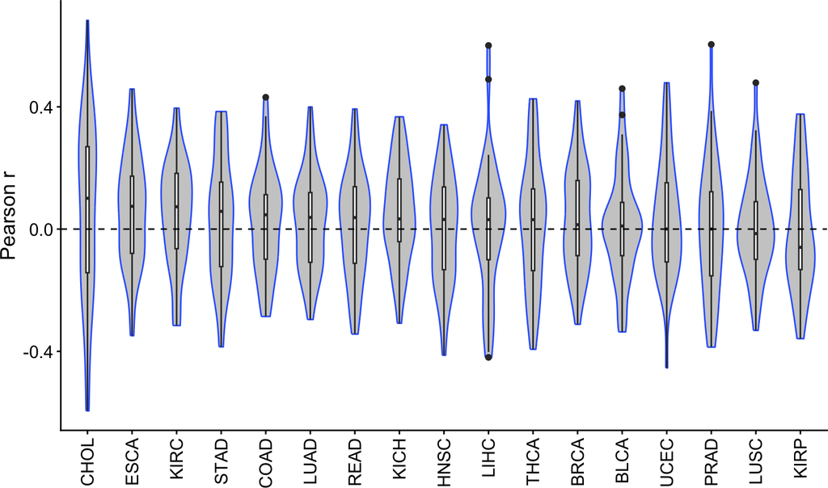

```r
p <- ggplot(cor_results, aes(x = cancer, y = r)) +
  geom_violin(fill = "grey80", colour = "#3366FF") +
  geom_boxplot(width = 0.07) +
  theme_classic() +
  ylab("Pearson r") +
  xlab("") +
  theme(axis.text=element_text(size=12),
        axis.title=element_text(size=14),
        axis.text.x = element_text(angle = 90, vjust = 0.5, hjust=1),
        legend.position = "none") +
  geom_hline(yintercept=0, linetype="dashed",
            color = "black", size=0.5)
p
```

```r
pdf(here("TCGA", "output", "figures", "TCGA_miRNA_act_vs_transcription_violin.pdf"), 7, 3.5)
p
dev.off()
```

# 9 Corresponding heatmap

```r
# Convert long to wide format with host gene/mir family pair as rows and cancers as columns
dat_htmp <- cor_results[, -(1:2)]
dat_htmp$pair <- paste(cor_results$gene_id, cor_results$miR_family, sep = "_")

dat_htmp <- dat_htmp %>%
  select(pair, cancer, r) %>%
  pivot_wider(
    names_from = cancer,
    values_from = r
  )

dat_htmp <- column_to_rownames(dat_htmp, "pair")
dat_htmp <- data.matrix(dat_htmp)

# Draw the heatmap
palette <- colorRampPalette(c("blue", "white", "red"))
pdf(here("TCGA", "output", "figures", "TCGA_miRNA_act_vs_transcription_htmp.pdf"), width=18, height=7)
heatmap.2(dat_htmp, trace="none", col=palette, cexRow=0.01, cexCol=2,  breaks=seq(-1,1,length.out=50), mar=c(10,10), keysize=1, hclust=function(x) hclust(x,method="complete"), distfun = function(x) dist(x,method = 'euclidean'), density.info = "none", key.par = list(cex=2), lhei=c(1,1.2), lwid = c(1,2), Colv = F, key.title = "", key.xlab = "Pearson r")
dev.off()
```

# 10 Average correlation between miRNA activity and rate of transcription of their primary transcripts

```r
mean(cor_results$r)
```

```
## [1] 0.02399139
```

# 11 Example scatter plot for miR-590-3p in LIHC

Helper functions to create scatter plots

```r
extract_mir_activity <- function(cancer, miR_act, miRNAs) {
  miR_act |>
    filter(cancer_type == cancer, sample_type == "tumor") |>
    filter(miRNA %in% miRNAs) |>
    select(sample_name, miRNA, coefficient_log2)
}

plot_mir_transc_vs_activity <- function(cancer, miRNA_fam, miR_act, dfi_long, save_pdf = NULL) {
  # Get the host gene of the pri-miRNA
  host_gene <- mir_gene_pairs_sig$gene_id[mir_gene_pairs_sig$miR_family == miRNA_fam]

  stopifnot(length(host_gene) == 1)

  # dfi for that cancer and host gene
  dfi_host <- dfi_long[dfi_long$cancer == cancer & dfi_long$gene_id == host_gene,  ]

  # Extract activity for the miRNA in that cancer (long format)
  miR_act_long <- extract_mir_activity(cancer, miR_act, miRNA_fam)

  # Match samples between activity and dfi
  common_samples <- intersect(unique(miR_act_long$sample_name), dfi_host$sample)
  dfi_host <- dfi_host |> filter(sample %in% common_samples)
  miR_act_long <- miR_act_long |> filter(sample_name %in% common_samples)

  # Sort by sample name for correct alignment
  miR_act_long <- miR_act_long |> arrange(factor(sample_name, levels = common_samples))
  dfi_host <- dfi_host |> arrange(factor(sample, levels = common_samples))
  dfi_samples <- dfi_host$sample
  dfi_vals <- dfi_host$dfi
  act_samples <- miR_act_long$sample_name
  act_vals <- miR_act_long$coefficient_log2

  # Verify sample names match in the same order
  stopifnot(
    "Transcription and activity samples must match in the same order" =
      all(dfi_samples == act_samples)
  )

  # Save to PDF
  if (!is.null(save_pdf)) {
    pdf(save_pdf, width = 3.5, height = 4.2)
  }

  # Create plot
  plot(dfi_vals, act_vals, pch = 16, cex = 0.5,
       xlab = paste0(miRNA_fam, " host gene\ntranscription log2FC"), ylab = paste0(miRNA_fam, " activity"),
       cex.axis = 0.8, cex.lab = 1.2)
  abline(lm(act_vals ~ dfi_vals), col = 4, lwd = 2)

  # Add correlation and p-value
  test_res <- cor.test(dfi_vals, act_vals)
  r <- test_res$estimate
  p <- test_res$p.value
  n <- length(dfi_vals)
  if (r > 0){
    text(min(dfi_vals, na.rm = TRUE), max(act_vals, na.rm = TRUE),
       paste0("r = ", round(r, 3), "\np = ", formatC(p, format = "e", digits = 3), "\nn = ", n),
       adj = c(0, 1), cex = 0.9)
  } else {
    text(max(dfi_vals, na.rm = TRUE)-1.5, max(act_vals, na.rm = TRUE),
       paste0("r = ", round(r, 3), "\np = ", formatC(p, format = "e", digits = 3), "\nn = ", n),
       adj = c(0, 1), cex = 0.9)
  }


  # Close PDF if it was opened
  if (!is.null(save_pdf)) {
    dev.off()
  }

  invisible(NULL)
}
```

```r
plot_mir_transc_vs_activity("LIHC", "miR-590-3p", miR_act,  dfi_long, save_pdf = here("TCGA", "output", "figures", "TCGA_miRNA_act_vs_transc_miR590_LIHC.pdf"))
```

# 12 Example scatter plot for miR-217 in LIHC

```r
plot_mir_transc_vs_activity("LIHC", "miR-217", miR_act,  dfi_long, save_pdf = here("TCGA", "output", "figures", "TCGA_miRNA_act_vs_transc_miR217_LIHC.pdf"))
```